# Project 2B: Streaming Data

Cooper Bodford, Alex Dodds, Zachary Dove, Lauren Rusnak

Sunday, April 10, 2022 @ 09:38 PM

## Setup

### Packages Used

```r
library(dplyr)
library(tidyverse)
library(tidyr)
library(ggplot2)
library(waffle)
```

### Background of the Data

The datasets were downloaded from [Disney+ Movies and TV Shows | Kaggle](https://www.kaggle.com/datasets/shivamb/disney-movies-and-tv-shows) and [TV shows on Netflix, Prime Video, Hulu and Disney+ | Kaggle](https://www.kaggle.com/datasets/ruchi798/tv-shows-on-netflix-prime-video-hulu-and-disney). You can read about them there, including variable definitions, sources, when they were created, and other information. Load the two datasets and use `glimpse()` to explore their structures.

#### Disney+ Dataset

```r
disney_plus_dataset <- read.csv("../data/disneypluscontent.csv", na.string = c(""))
glimpse(disney_plus_dataset)
```

```
Rows: 1,368
Columns: 12
$ show_id      <fct> s1, s2, s3, s4, s5, s6, s7, s8, s9, s10, s11, s12, s13, s…
$ type         <fct> Movie, Movie, Movie, TV Show, TV Show, TV Show, Movie, Mo…
$ title        <fct> "A Spark Story", "Spooky Buddies", "The Fault in Our Star…
$ director     <fct> "Jason Sterman, Leanne Dare", "Robert Vince", "Josh Boone…
$ cast         <fct> "Apthon Corbin, Louis Gonzales", "Tucker Albrizzi, Diedri…
$ country      <fct> NA, "United States, Canada", "United States", "United Sta…
$ date_added   <fct> 2021-09-24, 2021-09-24, 2021-09-24, 2021-09-22, 2021-09-2…
$ release_year <int> 2021, 2011, 2014, 2019, 2021, 2021, 2009, 2021, 2016, 202…
$ rating       <fct> TV-PG, G, PG-13, TV-PG, TV-Y, TV-PG, PG, TV-G, TV-G, TV-P…
$ duration     <fct> 88 min, 93 min, 127 min, 2 Seasons, 1 Season, 1 Season, 1…
$ listed_in    <fct> "Documentary", "Comedy, Fantasy, Kids", "Coming of Age, D…
$ description  <fct> "Two Pixar filmmakers strive to bring their uniquely pers…
```

#### Streaming Dataset

```r
streaming_dataset <- read.csv("../data/streamingcontent.csv", na.string = c(""))
glimpse(streaming_dataset)
```

```
Rows: 5,368
Columns: 10
$ ID              <int> 1, 2, 3, 4, 5, 6, 7, 8, 9, 10, 11, 12, 13, 14, 15, 16,…
$ Title           <fct> "Breaking Bad", "Stranger Things", "Attack on Titan", …
$ Year            <int> 2008, 2016, 2013, 2015, 2017, 2005, 2013, 2010, 2011, …
$ Age             <fct> 18+, 16+, 18+, 18+, 16+, 7+, 18+, 18+, 18+, 18+, 18+, …
$ IMDb            <fct> 9.4/10, 8.7/10, 9.0/10, 8.8/10, 8.8/10, 9.3/10, 8.8/10…
$ Rotten.Tomatoes <fct> 100/100, 96/100, 95/100, 94/100, 93/100, 93/100, 93/10…
$ Netflix         <int> 1, 1, 1, 1, 1, 1, 1, 1, 1, 1, 1, 1, 1, 1, 1, 1, 1, 1, …
$ Hulu            <int> 0, 0, 1, 0, 0, 0, 0, 0, 0, 0, 0, 1, 0, 1, 0, 0, 0, 0, …
$ Prime.Video     <int> 0, 0, 0, 0, 0, 1, 0, 0, 0, 0, 0, 1, 0, 1, 0, 0, 0, 0, …
$ Disney.         <int> 0, 0, 0, 0, 0, 0, 0, 0, 0, 0, 0, 0, 0, 0, 0, 0, 0, 0, …
```

```r
head(streaming_dataset)
```

```
  ID                      Title Year Age   IMDb Rotten.Tomatoes Netflix Hulu
1  1               Breaking Bad 2008 18+ 9.4/10         100/100       1    0
2  2            Stranger Things 2016 16+ 8.7/10          96/100       1    0
3  3            Attack on Titan 2013 18+ 9.0/10          95/100       1    1
4  4           Better Call Saul 2015 18+ 8.8/10          94/100       1    0
5  5                       Dark 2017 16+ 8.8/10          93/100       1    0
6  6 Avatar: The Last Airbender 2005  7+ 9.3/10          93/100       1    0
  Prime.Video Disney.
1           0       0
2           0       0
3           0       0
4           0       0
5           0       0
6           1       0
```

## Analyses

### Create the Analysis Datasets

#### Dataset #1

The Disney+ dataset contains a variable that gives information about the `rating` for each program offering. Convert the variable into a factor that puts the ratings in (roughly) ascending order of age restriction/audience: `TV-Y`, `TV-Y7`, `TV-Y7-FV`, `TV-G`, `G`, `TV-PG`, `PG`, `PG-13`, `TV-14`. If the `date_added` variable is not already in date format, convert it.

```r
disney_plus_mutated <- disney_plus_dataset %>%
  mutate(rating = factor(rating,
    levels = c(
      "TV-Y",
      "TV-Y7",
      "TV-Y7-FV",
      "TV-G",
      "G",
      "TV-PG",
      "PG",
      "PG-13",
      "TV-14"
    )
  )) %>%
  arrange(rating)

glimpse(disney_plus_mutated)
```

```
Rows: 1,368
Columns: 12
$ show_id      <fct> s5, s16, s22, s23, s36, s45, s60, s61, s73, s74, s94, s10…
$ type         <fct> TV Show, TV Show, TV Show, TV Show, TV Show, TV Show, TV …
$ title        <fct> "Spidey And His Amazing Friends", "Ready for Preschool", …
$ director     <fct> NA, NA, NA, NA, NA, NA, NA, NA, NA, NA, NA, NA, NA, NA, N…
$ cast         <fct> "Benjamin Valic, Lily Sanfelippo, Jakari Fraser, Dee Brad…
$ country      <fct> "United States", NA, "United States", "United States", "F…
$ date_added   <fct> 2021-09-22, 2021-09-15, 2021-09-08, 2021-09-08, 2021-08-2…
$ release_year <int> 2021, 2019, 2020, 1997, 2018, 2021, 2018, 2021, 2021, 201…
$ rating       <fct> TV-Y, TV-Y, TV-Y, TV-Y, TV-Y, TV-Y, TV-Y, TV-Y, TV-Y, TV-…
$ duration     <fct> 1 Season, 1 Season, 2 Seasons, 3 Seasons, 2 Seasons, 1 Se…
$ listed_in    <fct> "Action-Adventure, Animation, Kids", "Kids, Music", "Anim…
$ description  <fct> "Spidey teams up with pals to become The Spidey Team!", "…
```

#### Dataset #2

From the streaming content dataset, create a new dataset by doing the following.

- Use `pivot_longer()` to gather the `Netflix`, `Hulu`, `Prime Video`, and `Disney+` variables into columns called `Service` (containing the name of the streaming service) and `YesNo` (showing the 0/1 indicator values from the original columns).
- After pivoting, filter the dataset to remove any row where `YesNo == 0` (i.e., a show is *not* on the service).
- Split the `IMDb` variable to separate the show rating from the max rating of `10`. Convert the show rating to a numerical variable.
- Split the `Rotten Tomatoes` variable to separate the show rating from the max of `100`. Convert the show rating to a numerical variable.

```r
streaming_dataset_long <- streaming_dataset %>%
  pivot_longer(
    cols = `Netflix`:`Disney.`, # what columns are getting stacked up
    names_to = "Series",      # where will the column names go to
    values_to = "YesNo"     # what is the new name of the stacked data
  ) %>%
  filter(YesNo == 1) %>%
  separate(
    col = `IMDb`, # which column to separate
    into = c("IMDb_Show_Rating", "IMDb_Max_Rating"), # names of new columns, must be in quotes
    sep = "/", # how numbers/data is separated in the of column
    remove = TRUE, # Default is shown. to keep original column, use FALSE
    convert = FALSE, # Default so can erase
    extra = "warn", # Default so can erase
    fill = "warn" # Default so can erase
    ) %>%
  separate(
    col = `Rotten.Tomatoes`, # which column to separate
    into = c("RT_Show_Rating", "RT_Max_Rating"), # names of new columns, must be in quotes
    sep = "/", # how numbers/data is separated in the of column
    remove = TRUE, # Default is shown. to keep original column, use FALSE
    convert = FALSE, # Default so can erase
    extra = "warn", # Default so can erase
    fill = "warn" # Default so can erase
  )

head(streaming_dataset_long)
```

```
# A tibble: 6 × 10
     ID Title         Year Age   IMDb_Show_Rating IMDb_Max_Rating RT_Show_Rating
  <int> <fct>        <int> <fct> <chr>            <chr>           <chr>
1     1 Breaking Bad  2008 18+   9.4              10              100
2     2 Stranger Th…  2016 16+   8.7              10              96
3     3 Attack on T…  2013 18+   9.0              10              95
4     3 Attack on T…  2013 18+   9.0              10              95
5     4 Better Call…  2015 18+   8.8              10              94
6     5 Dark          2017 16+   8.8              10              93
# … with 3 more variables: RT_Max_Rating <chr>, Series <chr>, YesNo <int>
```

```r
streaming_dataset_long$RT_Show_Rating <- as.numeric(streaming_dataset_long$RT_Show_Rating)
streaming_dataset_long$IMDb_Show_Rating <- as.numeric(streaming_dataset_long$IMDb_Show_Rating)
head(streaming_dataset_long)
```

```
# A tibble: 6 × 10
     ID Title         Year Age   IMDb_Show_Rating IMDb_Max_Rating RT_Show_Rating
  <int> <fct>        <int> <fct>            <dbl> <chr>                    <dbl>
1     1 Breaking Bad  2008 18+                9.4 10                         100
2     2 Stranger Th…  2016 16+                8.7 10                          96
3     3 Attack on T…  2013 18+                9   10                          95
4     3 Attack on T…  2013 18+                9   10                          95
5     4 Better Call…  2015 18+                8.8 10                          94
6     5 Dark          2017 16+                8.8 10                          93
# … with 3 more variables: RT_Max_Rating <chr>, Series <chr>, YesNo <int>
```

### Visualization 1: Violin Plot

**This plot uses Dataset #1.**

Create a violin plot of `release_year` (x-axis) grouped by `type` of program (y-axis) for programs on Disney+. Fill with a color of your choice. Add a boxplot inside the violin plot, as you did in one of the DataCamp exercises. Re-scale the x-axis so that tick marks appear at whole-decade intervals (e.g., 1980, 1990, 2000). Add an appropriate title and axis labels. Use other formatting as you choose to enhance effectiveness/appearance.

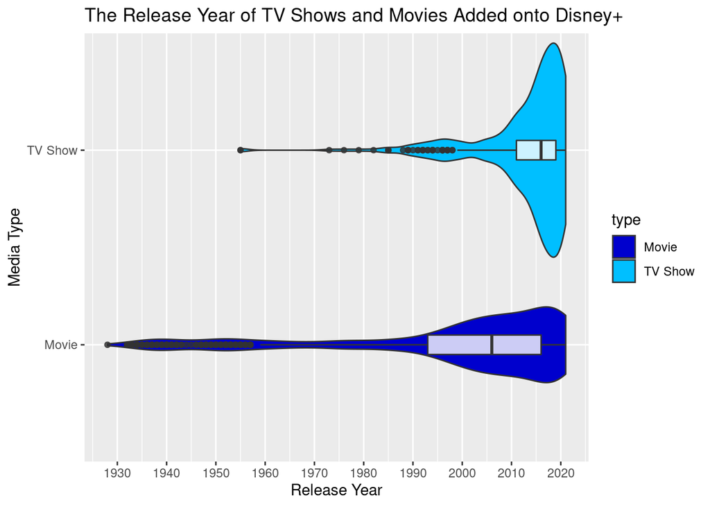

```r
disney_plus_mutated %>%
  ggplot(aes(x = release_year, y = type, fill = type)) +
  geom_violin(width = 1.1) +
  geom_boxplot(width = 0.1, alpha = 0.8, fill = 'white') +
  scale_x_continuous(breaks = seq(from = 1920, to = 2030, by = 10)) +
  labs(title = "The Release Year of TV Shows and Movies Added onto Disney+",
       x = "Release Year",
       y = "Media Type") +
   scale_fill_manual(values = c('mediumblue', 'deepskyblue'))
```

### Visualization 2: Waffle Plot

**This plot uses Dataset #1.**

Create a waffle plot to show the distribution of program `type` on Disney+.

- Give the plot the title “Streaming Content on Disney+”.
- Change the colors of the squares to something other than the defaults.
- Use an x-axis label to indicate roughly how many programs each square represents.

Hint: Use `round(100 * prop.table(table(DATASETNAME$VARIABLENAME)))` to create the input data for the waffle plot. Swap out the capital letter placeholders for the correct dataset name and variable name.

```r
disney_plus_mutated %>%
  count(type)
```

```
     type   n
1   Movie 991
2 TV Show 377
```

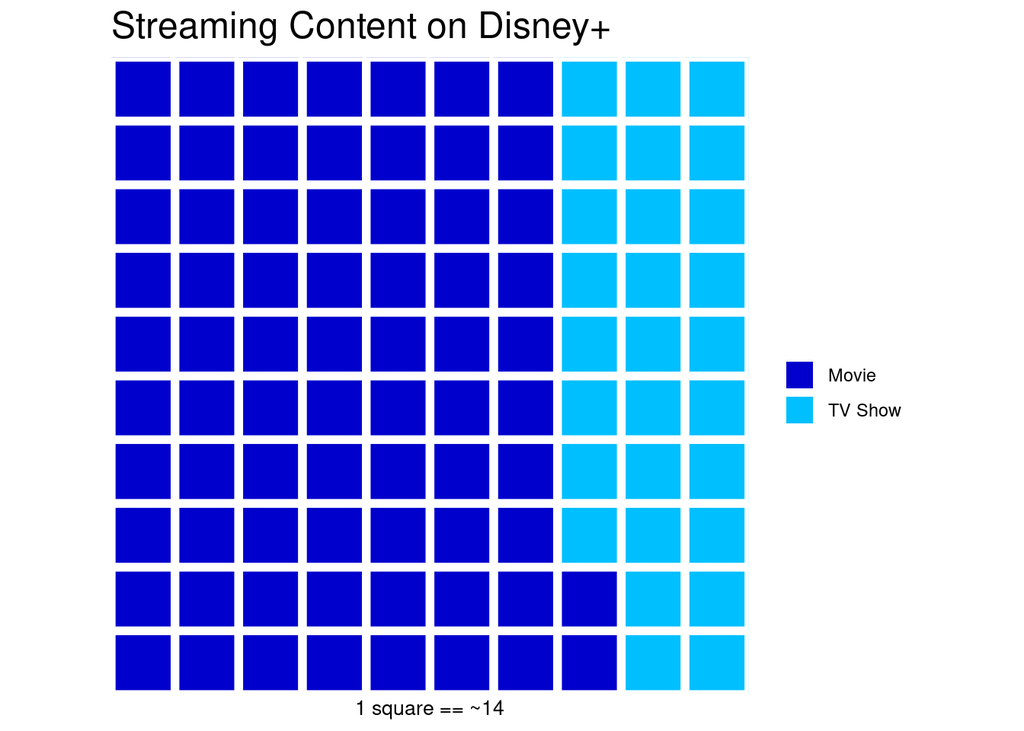

```r
round(100 * prop.table(table(disney_plus_mutated$type))) %>%
  waffle(rows = 10,
         colors = c('mediumblue', 'deepskyblue'),
         xlab = '1 square == ~14') +
  labs(title = "Streaming Content on Disney+")
```

### Visualization 3: Ratings Bar Plot

**This plot uses Dataset #1.**

Create a horizontal barplot to show the frequencies of the various `rating` categories for programs on Disney+ (i.e., use `y =` rather than `x =` for the variable you are plotting). **You will need to remove a couple `NA` values first.** Facet by `type` so that you have side-by-side plots for the two different program types. Add an appropriate title and axis labels, as well as other formatting to enhance effectiveness/appearance.

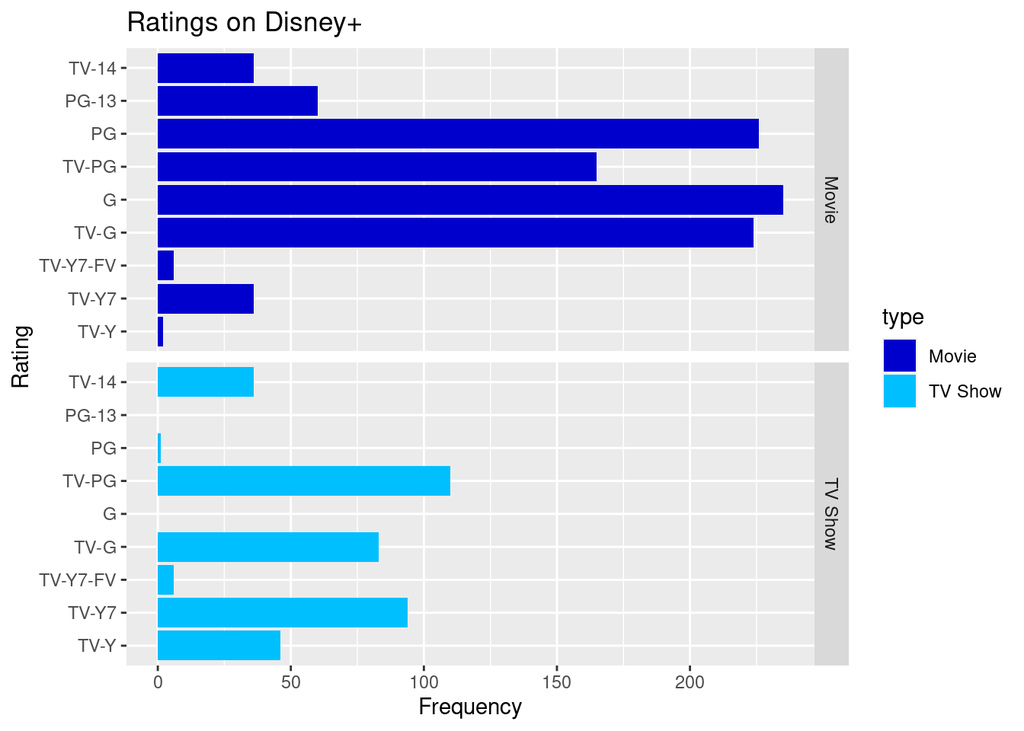

```r
disney_plus_mutated %>%
  drop_na(rating) %>%
  ggplot(aes(y = rating, fill = type)) +
  geom_bar() +
  facet_grid(rows = vars(type)) +
  scale_fill_manual(values = c('mediumblue', 'deepskyblue')) +
  labs(title = "Ratings on Disney+",
       x = "Frequency",
       y = "Rating")
```

### Visualization 4: Services Bar Plot

**This plot uses Dataset #2.**

Create a barplot to display how many shows are offered on each of the four streaming services. Choose appropriate colors, labels, themes, and/or and other types of formatting that you feel will enhance the meaning or visual appearance of the plot.

```r
streaming_data_count <- streaming_dataset_long %>%
count(Series, YesNo)
```

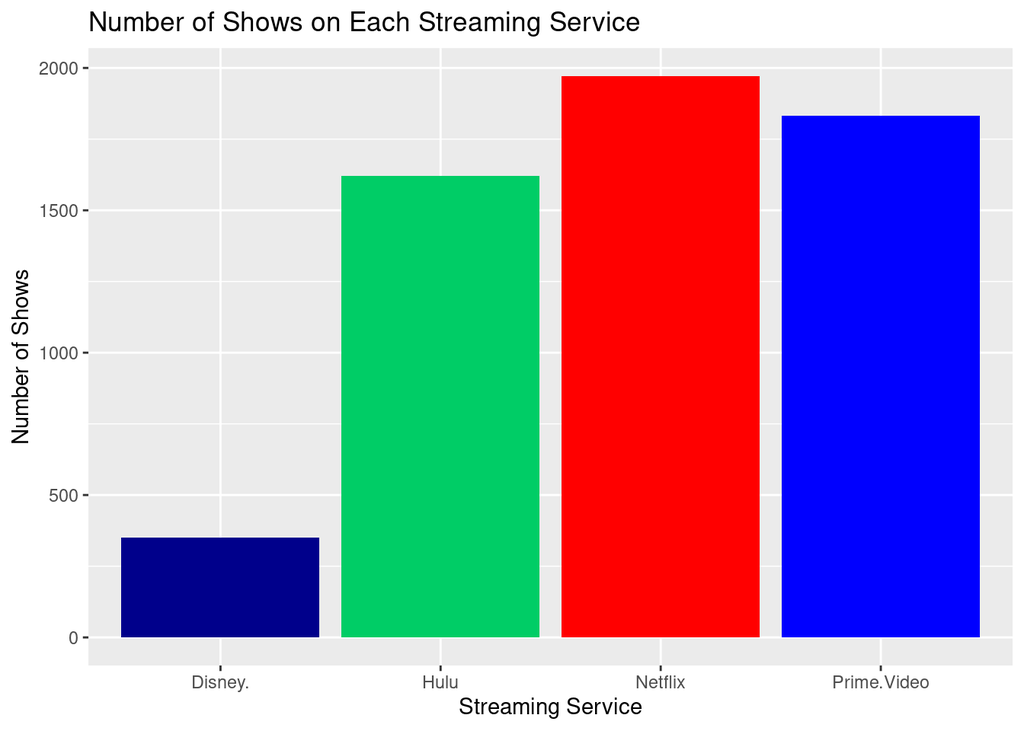

```r
streaming_data_count %>%
  ggplot(aes(x = Series, y = n)) +
  geom_col(fill = c('blue4', 'springgreen3', 'red1', 'blue'))+
  labs(title = "Number of Shows on Each Streaming Service",
       x = "Streaming Service",
       y = "Number of Shows")
```

### Visualization 5: Choose a Plot!

Create one other plot of your choice using either dataset to explore a question of interest. You are welcome to perform additional manipulations on the data, if needed. Add an appropriate title and axis labels, as well as any other necessary formatting.

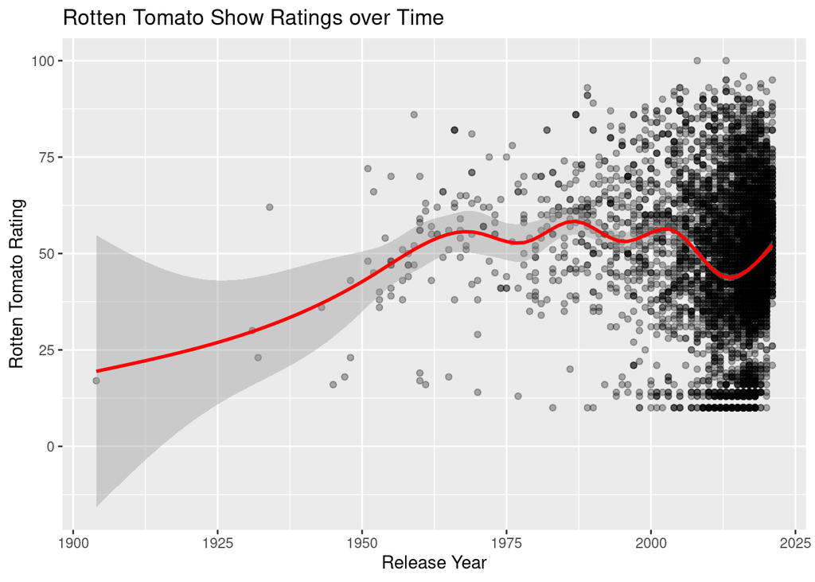

```r
streaming_dataset_long %>%
  ggplot(aes(x = Year, y = RT_Show_Rating)) +
  geom_point(alpha = 0.3) +
  geom_smooth(color = 'red') +
  labs(title = "Rotten Tomato Show Ratings over Time",
       y = "Rotten Tomato Rating",
       x = "Release Year")
```

## Questions

**Question 1:** Based on your plots, make five informational statements or comparisons regarding the Disney+ streaming service.

**Question 2:** What other data would you like to have, or which existing variables would you like to see transformed, if you were going to do further explorations or visualizations? Give at least two examples.

**ANSWER**

We would like to see the total count of movies and TV Shows in different decades displayed in a bar graph to be able to measure the exact percent change over the years to compare the growth between TV shows and movies.

We would also like to see the years in which all the programs were added to Disney+ and the rating of each program to determine the direction Disney+ has taken over the year in terms of what kind of programs they want available to stream on their platform. The data would tell us the type of audience Disney+ is aiming for and how it has changed over time.

**Question 3:** Explain the rationale behind the choices you made with regard to plot type, formatting, and so on, when you created Visualization 5. What motivated your decisions?

**ANSWER**

We wanted to visualize how the Rotten Tomato has scored tv shows with different release dates. We decided to make a scatter plot of the release year versus the Rotten Tomato scores to show the relationship between these two variables. To show the trend better we added a trendline. To show density and distinguish between each data point, we made each point somewhat transparent. We decided to keep the shaded region to show error because of the small sample size of tv shows released before 1975.